# Prestadores: Prueba Técnica

Jorge Luis Aquino Olmos

2024-04-06

### 1. Carga de los datos

Carga de los datos: Se ha encontrado un problema al intentar cargar el archivo prestadores.csv debido a un error de codificación, que suele surgir cuando el archivo contiene caracteres que no están en el formato UTF-8. Para resolver este inconveniente, se adoptó la estrategia de cargar el archivo especificando una codificación diferente, como ‘ISO-8859-1’ o ‘latin1’, que son comunes en archivos que incluyen caracteres especiales no presentes en el alfabeto inglés. Esta acción permitió sortear el obstáculo inicial relacionado con la codificación del archivo, asegurando que los caracteres especiales se interpreten correctamente durante el proceso de carga.

Posteriormente, se procedió a superar desafíos adicionales relacionados con la codificación y delimitación del archivo prestadores.csv. Específicamente, se estableció la codificación como ‘ISO-8859-1’ y se especificó el delimitador como ‘;’ para asegurar una interpretación precisa de los datos. Este enfoque permitió una carga exitosa del archivo, garantizando que los caracteres especiales se manejen adecuadamente y que la estructura tabular de los datos se preserve correctamente. Con estos ajustes, se allanó el camino para realizar un análisis exploratorio y descriptivo más detallado de los datos contenidos en el archivo prestadores.csv.

### 2. Análisis Descriptivo General

Comenzaremos con un análisis descriptivo general de ambos datasets para tener una visión global de los datos. Dataset prestadores:

El dataset de prestadores de servicios contiene información diversa sobre 60,946 registros únicos, distribuidos en 38 departamentos y 914 municipios diferentes. Algunas observaciones clave incluyen:

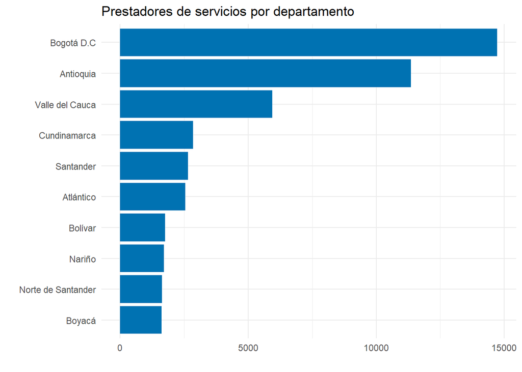

### 3. Municipios

La distribución geográfica y demográfica de los municipios colombianos es un reflejo de la variedad de paisajes y poblaciones que conforman el país, desde las zonas urbanas densamente pobladas hasta las regiones rurales dispersas. En este sentido, nos sumergimos en el estudio de características clave como la población, la superficie y el índice de ruralidad de cada municipio, reconociendo la importancia de estos datos para la planificación y el desarrollo equitativo a nivel local y nacional.

Por ello no podemos pasar por alto la relevancia de los prestadores de servicios en este análisis. La distribución de estos proveedores en los diferentes municipios no solo refleja las dinámicas económicas y sociales de cada región, sino que también tiene un impacto significativo en el acceso y la calidad de los servicios disponibles para la población. Por lo tanto, al explorar la diversidad geográfica y demográfica de Colombia, también nos enfocamos en entender la distribución de los prestadores de servicios y su relación con las características locales.

| (Top 10) Población y superficie por Departamento Departamento | (Top 10) Población y superficie por Departamento Población | (Top 10) Población y superficie por Departamento Superficie |
| --- | --- | --- |
| Bogotá D.C | 7592871 | 1622.853 |
| Antioquia | 6550206 | 62804.709 |
| Valle del Cauca | 4506768 | 20665.545 |
| Cundinamarca | 3085522 | 22370.489 |
| Atlántico | 2638151 | 3315.752 |
| Santander | 2237587 | 30561.498 |
| Bolívar | 2120925 | 26302.810 |
| Córdoba | 1741111 | 24454.516 |
| Nariño | 1628981 | 31497.573 |
| Norte de Santander | 1565362 | 21856.754 |

### 4. Relación entre la Cantidad de Prestadores y Características Demográficas de los Municipios

Para explorar la relación entre la cantidad de prestadores de servicios y las características demográficas de los municipios (población y superficie), necesitaríamos combinar la información de los dos datasets. Debido a la variabilidad en la codificación de los nombres de los municipios y departamentos, este paso puede requerir una normalización de los datos para asegurar una combinación precisa.

Sin embargo, la inspección inicial sugiere que una mayor población en un municipio podría correlacionarse con una mayor cantidad de prestadores, dado el número elevado de prestadores en Bogotá D.C. Este patrón probablemente se repita en otros centros urbanos principales.

Para realizar un análisis de clusterización con los datos disponibles, primero necesitamos definir las características (variables) que utilizaremos para agrupar los datos. Dado que tenemos dos conjuntos de datos principales, podríamos considerar varias opciones:

Prestadores de Servicios: Utilizar características como la naturaleza jurídica, el tipo de prestador, entre otros, para agrupar los prestadores de servicios. Sin embargo, muchas de estas variables son categóricas y requerirían un preprocesamiento adecuado (por ejemplo, codificación One-Hot) antes de la clusterización.

Municipios: Utilizar datos demográficos y geográficos, como población, superficie, e índice de ruralidad para agrupar los municipios. Esta opción parece más directa y podría ofrecer insights interesantes sobre cómo se agrupan los municipios según sus características.

```
## Cantidad de municipios en prestadores = 914
```

```
## Cantidad de municipios en Municipios = 1030
```

```
## Cantidad de municipios en prestadores que no están en Municipios = 106
```

```
## Cantidad de municipios en Municipios que no están en prestadores = 222
```

Es evidente que existen discrepancias notables en los nombres de los municipios entre ambos conjuntos de datos. Este hallazgo subraya la importancia de abordar las discrepancias en la fuente de datos para garantizar la integridad y precisión de nuestro análisis. Tras una revisión exhaustiva, he identificado que las discrepancias en los nombres de los departamentos son considerablemente menores y, por ende, más manejables. Además, las diferencias encontradas en esta característica fueron subsanadas mediante el procedimiento previamente realizado y las correcciones aplicadas. Por consiguiente, hemos decidido enfocarnos en la unificación de características a través de los departamentos, aprovechando su menor número y las diferencias menos significativas encontradas en este nivel de agregación.

### 5. Análisis de Clúster

Utilizaré los datos demográficos y geográficos disponibles, tales como población, superficie e índice de ruralidad, para agrupar los departamentos. Esta estrategia nos brindará valiosos insights sobre cómo se organizan los departamentos en función de sus características, permitiéndonos identificar patrones y tendencias en la agrupación departamental basados en dichos atributos. Al concluir esta agrupación, procederemos a integrar ambos datasets para explorar la relación entre la cantidad de prestadores de servicios y las características demográficas de los municipios, enriqueciendo así nuestra comprensión de la estructura demográfica y geográfica del país, así como de las dinámicas que influyen en la distribución y configuración de los departamentos. Este enfoque integral no solo iluminará aspectos clave de la distribución de servicios en el territorio sino que también facilitará una evaluación más detallada de cómo las características de cada departamento afectan la disponibilidad y el acceso a dichos servicios.

### 5.1 Limpieza y preparación de los datos

```
## 'data.frame':    1118 obs. of  4 variables:
##  $ Departamento: chr  "Antioquia" "Antioquia" "Antioquia" "Antioquia" ...
##  $ Poblacion   : int  2483545 20258 2710 4669 30777 26552 43713 5790 11462 18737 ...
##  $ Superficie  : chr  "374.8306248" "507.1341142" "296.9559801" "128.9321532" ...
##  $ Irural      : int  5 45 58 48 28 54 38 37 47 58 ...
```

```
## 'data.frame':    1118 obs. of  4 variables:
##  $ Departamento: chr  "Antioquia" "Antioquia" "Antioquia" "Antioquia" ...
##  $ Poblacion   : int  2483545 20258 2710 4669 30777 26552 43713 5790 11462 18737 ...
##  $ Irural      : int  5 45 58 48 28 54 38 37 47 58 ...
##  $ Superficie  : num  374.8 507.1 297 128.9 84.1 ...
```

### 6. Agrupamiento por K-Medios (K-Means Clustering)

[figure not shown]

Si bien es cierto que un valor más alto de la métrica de silueta sugiere una mejor separación entre los clusters, la elección del número óptimo de clusters también debe tomar en cuenta el contexto específico y el conocimiento del dominio. En ocasiones, es preferible seleccionar un número de clusters que sea más fácil de interpretar y tenga una mayor aplicabilidad práctica, incluso si esto significa no alcanzar el valor máximo de silueta. En este contexto, considero adecuado elegir K = 6, basándonos en el punto pico de la curva de silueta y en un punto medio de esta métrica. Esto nos permite lograr una agrupación efectiva de los datos mientras evitamos la sobreagrupación de entidades, lo que facilita la interpretación de los resultados y su aplicación en el contexto específico del problema.

La clusterización de los municipios en seis grupos nos ofrece una interesante perspectiva sobre cómo se diferencian entre sí según las variables seleccionadas (población, superficie e índice de ruralidad):

| Cluster | Cardinalidad | Media_Poblacion | Media_Superficie | Media_Irural | Moda_Irural |
| --- | --- | --- | --- | --- | --- |
| 6 | 1 | 7592871.00 | 1622.8526 | 6.00000 | 6 |
| 1 | 19 | 739644.42 | 516.8377 | 14.84211 | 12 |
| 5 | 450 | 36854.10 | 237.8359 | 37.54444 | 42 |
| 2 | 23 | 20057.43 | 17994.9797 | 83.91304 | 81 |
| 3 | 48 | 18448.98 | 4846.2359 | 75.47917 | 67 |
| 4 | 577 | 16848.50 | 651.4211 | 51.24090 | 48 |

| Cluster | Cardinalidad | Media_Poblacion | Media_Superficie | Media_Irural | Prestadores |
| --- | --- | --- | --- | --- | --- |
| 6 | 1 | 7592871.00 | 1622.8526 | 6.000000 | 14728 |
| 1 | 13 | 905612.44 | 288.4162 | 9.495442 | 34236 |
| 5 | 23 | 35126.08 | 213.2025 | 36.838220 | 42350 |
| 2 | 8 | 25652.13 | 16508.6859 | 78.716768 | 1781 |
| 4 | 26 | 17470.60 | 656.0608 | 50.469196 | 43340 |
| 3 | 13 | 13491.98 | 2873.3448 | 67.980272 | 14944 |

### Análisis conjunto prestadores y deparatmentos

El análisis de clusterización ha revelado una diversidad notable en la estructura de los departamentos de Colombia, mostrando variaciones en urbanización, tamaño y accesibilidad de servicios. Los departamentos agrupados en clusters con altas cifras de población y baja ruralidad exhiben una abundancia de prestadores de servicios, un reflejo directo de la demanda intensa característica de zonas urbanizadas con alta densidad de población. Esta correlación subraya la capacidad de las áreas metropolitanas para sostener y atraer una variedad de servicios, satisfaciendo así una gama más amplia de necesidades ciudadanas.

Por otro lado, los clusters identificados por su marcada ruralidad evidencian un número menor de prestadores de servicios. Este patrón plantea interrogantes sobre la accesibilidad y suficiencia de los servicios en áreas rurales, lo que podría significar desafíos en términos de cobertura y calidad. Estos departamentos rurales pueden enfrentar obstáculos sustanciales que afectan la provisión de servicios esenciales, desde la atención de la salud hasta la educación y el comercio.

Este análisis sirve como un punto de partida estratégico para la asignación equitativa de recursos y la elaboración de políticas públicas que se ajusten a las necesidades de cada cluster de departamentos. La creación de políticas adaptadas a estas agrupaciones podría optimizar los resultados y asegurar que los servicios estén disponibles donde más se necesiten.

Para profundizar en este estudio, sería conveniente investigar la calidad y el espectro de los prestadores de servicios en cada cluster de departamentos. Un entendimiento detallado de estos factores contribuiría a una imagen más completa de cómo los servicios actuales satisfacen las demandas de las poblaciones locales y revelaría oportunidades para mejoras y expansiones en sectores donde existen déficits.

En conjunto, el análisis demuestra la importancia de considerar la demografía y la geografía en la planificación de servicios y subraya la necesidad de estrategias diferenciadas que puedan abordar las disparidades en la distribución y calidad de los servicios entre los departamentos urbanos y rurales de Colombia.